# Vivid Volcano: Empowering Non-Bioinformaticians to Analyze Pre-Processed Omics Data

# Figures

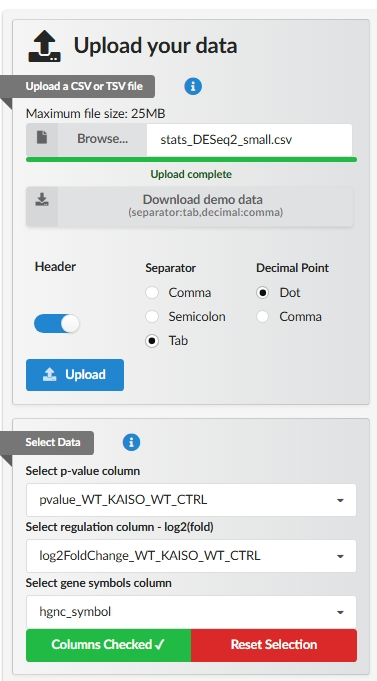

Fig.1. Data upload and data select and curation modules of the Vivid Volcano application

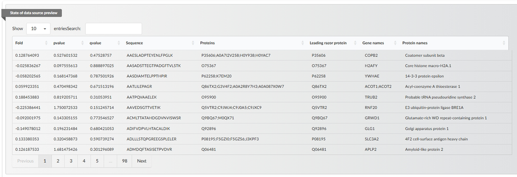

Fig.2. Interactive datatable preview of the analyzed data in the Vivid Volcano application.

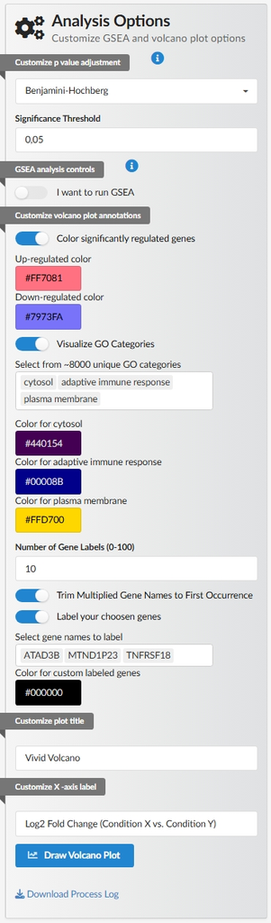

Fig.3.Volcano plot customisation options in the Vivid Volcano application

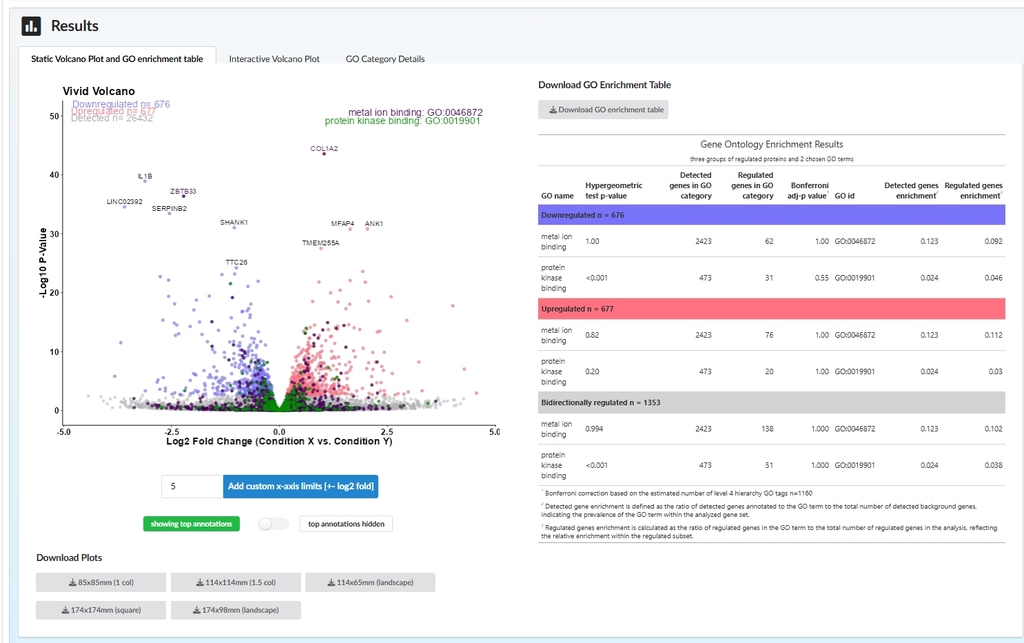

Fig.4. Volcano plot and publication ready tabular results generated with Vivid Volcano application

[figure not shown]

Fig.5. The results of Gene Set Enrichment analysis performed with VIvid Volcano application

# Acknowledgements

The author would like to thank all the beta users especially Konrad Kowalski and dr Anna Marusiak for their feedback and suggestions that helped to improve the application.

The author would like to thank the developers of R, RStudio, and the R community for providing the tools and support necessary to create this work.

# AI statement

The author used Claude Sonnet 3.7 to copy edit and proofread the manuscript. The author has reviewed generated fragments and corrections to the text to ensure its accuracy and coherence.

# References

Attali, Dean. 2021. “Shinyjs: Easily Improve the User Experience of Your Shiny Apps in Seconds.” https://deanattali.com/shinyjs/.

Attali, Dean, and Tristan Edwards. 2024. “Shinyalert: Easily Create Pretty Popup Messages (Modals) in ’Shiny’.” https://github.com/daattali/shinyalert.

Chang, Winston, Joe Cheng, JJ Allaire, Carson Sievert, Barret Schloerke, Yihui Xie, Jeff Allen, Jonathan McPherson, Alan Dipert, and Barbara Borges. 2024. “Shiny: Web Application Framework for r.” https://CRAN.R-project.org/package=shiny.

Iannone, Richard, Joe Cheng, Barret Schloerke, Ellis Hughes, Alexandra Lauer, JooYoung Seo, Ken Brevoort, and Olivier Roy. 2024. “Gt: Easily Create Presentation-Ready Display Tables.” https://gt.rstudio.com.

Manzoni, Claudia, Demis A Kia, Jana Vandrovcova, John Hardy, Nicholas W Wood, Patrick A Lewis, and Raffaele Ferrari. 2018. “Genome, Transcriptome and Proteome: The Rise of Omics Data and Their Integration in Biomedical Sciences.” *Briefings in Bioinformatics* 19 (2): 286–302. https://doi.org/10.1093/bib/bbw114.

Sievert, Carson. 2020. “Interactive Web-Based Data Visualization with r, Plotly, and Shiny.” https://plotly-r.com.

Stachura, Filip, Dominik Krzeminski, Krystian Igras, Adam Forys, Paweł Przytuła, Jakub Chojna, Olga Mierzwa-Sulima, Jakub Nowicki, and Tymoteusz Makowski. 2024. “Shiny.semantic: Semantic UI Support for Shiny.” https://appsilon.github.io/shiny.semantic/.

Wickham, Hadley. 2016. “Ggplot2: Elegant Graphics for Data Analysis.” https://ggplot2.tidyverse.org.

Wickham, Hadley, Romain François, Lionel Henry, Kirill Müller, and Davis Vaughan. 2023. “Dplyr: A Grammar of Data Manipulation.” https://dplyr.tidyverse.org.

Wickham, Hadley, Davis Vaughan, and Maximilian Girlich. 2024. “Tidyr: Tidy Messy Data.” https://tidyr.tidyverse.org.

Xie, Yihui, Joe Cheng, and Xianying Tan. 2024. “DT: A Wrapper of the JavaScript Library ’DataTables’.” https://github.com/rstudio/DT.